# Orchid Pollinators — Global Distribution

- Show All Code
- Hide All Code
- View Source

Author

Raymond L. Tremblay, Natalia Palou, Caleb Pacheco and Naan Lamoso

Published

16 August 2026

## Introduction

Orchidaceae is among the largest families of flowering plants, and its pollination systems are correspondingly diverse. Records of who pollinates what, however, are scattered across a century of primary literature and are rarely tied to explicit coordinates, which makes the geography of orchid pollination difficult to examine directly.

This document maps the georeferenced portion of a global compilation of orchid pollination records. The underlying database was assembled by Ackerman *et al.* (2023) and covers roughly 3,100 species; the work presented here adds coordinates to those records, species by species, from the localities reported in the source publications.

Georeferencing is in progress and proceeds by region, the Americas first and Asia to follow. The maps below therefore show the records resolved to date rather than the full database, and coverage is uneven between subfamilies.

Each point is interactive: pan and zoom, click a marker for the species, locality, traits and named pollinators, and use the checkboxes at the upper right to show or hide individual pollinator groups.

### Data source

Pollination records are drawn from the global orchid pollination database of Ackerman JD, Phillips RD, Tremblay RL, Karremans A, Reiter N, Peter CI, Bogarín D, Pérez-Escobar OA & Liu H (2023), *Beyond the various contrivances by which orchids are pollinated: global patterns in orchid pollination biology*, **Botanical Journal of the Linnean Society** 202: 295–324, archived at https://doi.org/10.5281/zenodo.7263689 under CC BY 4.0.

## Packages

```r
library(readxl)   # read Excel files (.xlsx, .xls)
library(openxlsx) # read the enriched workbook's sheets
library(dplyr)    # data manipulation: filter, mutate, count, the %>% pipe
library(tidyr)    # tidyr::fill() -- carries a value down into blank rows
library(stringr)  # text/pattern helpers, mainly str_detect()
library(ggplot2)  # the coverage / composition figure
library(leaflet)  # interactive maps
```

## Loading and preparing the data

The `species` sheet of the enriched workbook is read and its column names are normalised.

```r
# Path to the enriched workbook. This is the ONLY place the file name lives:
# if it is renamed, change just this line.
data_path <- "Pollination_List_pollinators_enriched.xlsx"

# The `species` sheet drives the map; `pollinators_long` drives the drill-down.
data      <- read.xlsx(data_path, sheet = "species")
poll_long <- read.xlsx(data_path, sheet = "pollinators_long")

# Why clean the column names:
# the headers can have inconsistent capitalization and stray trailing spaces.
# We trim and lowercase once here so the rest of the code relies on tidy names.
colnames(data) <- tolower(trimws(colnames(data)))

# A stable row id per record, matching pollinators_long$row (same sheet order).
data$row <- seq_len(nrow(data))
```

Columns are identified **by name rather than by position**. The workbook grows and is periodically reordered, so matching on name keeps the code stable when a column moves.

```r
# Helper: given all column names and a search pattern, return the FIRST
# column name that matches, or NA if none matches.
find_col <- function(col_names, pattern) {
  found <- col_names[str_detect(col_names, pattern)]
  if (length(found) == 0) NA_character_ else found[1]
}

col_names <- names(data)
lat_col   <- find_col(col_names, "lat")              # e.g. "latitud"
lon_col   <- find_col(col_names, "lon")              # e.g. "longitud"
# Two pollinator columns, and the order matters -- see the note in the next
# chunk. `poll_groups` is the one derived by the wrangling doc from the
# free-text `pollinators` cell; `pollinator_type` is the older hand-typed column.
grp_col   <- find_col(col_names, "^poll_groups$")    # preferred: the parsed groups
poll_col  <- find_col(col_names, "^pollinator_type$")# fallback: the legacy column
if (is.na(poll_col)) poll_col <- find_col(col_names, "pollinator_type")
loc_col   <- find_col(col_names, "locality|localidad|sitio|lugar")
spec_col  <- find_col(col_names, "^species$|especie|taxon")
# "^genus$" matches the column named EXACTLY "genus". A loose "genus" pattern
# would also catch "genus count", which is a different column.
genus_col <- find_col(col_names, "^genus$")
subf_col  <- find_col(col_names, "^subfamily$")

# Coordinates are essential. If they are missing, stop now with a clear message.
if (is.na(lat_col) || is.na(lon_col)) {
  stop("No latitude/longitude columns were found in the 'species' sheet.")
}

cat("Latitude column:  ", lat_col,   "\n")
```

```
Latitude column:   latitud
```

```r
cat("Longitude column: ", lon_col,   "\n")
```

```
Longitude column:  longitud
```

```r
cat("Pollinator group column (preferred):", grp_col,  "\n")
```

```
Pollinator group column (preferred): poll_groups
```

```r
cat("Pollinator type column (fallback):  ", poll_col, "\n")
```

```
Pollinator type column (fallback):   pollinator_type
```

```r
cat("Genus column:     ", genus_col, "\n")
```

```
Genus column:      genus
```

```r
cat("Subfamily column: ", subf_col,  "\n")
```

```
Subfamily column:  subfamily
```

```r
# Coordinates arrive as TEXT, sometimes with stray spaces or a comma as the
# decimal separator ("18,234"). This helper turns that text into clean numbers.
to_number <- function(x) {
  x <- gsub("\\s+", "", x)  # remove any spaces
  x <- gsub(",", ".", x)    # comma -> dot, because R needs a dot decimal
  suppressWarnings(as.numeric(x))
}

# Carry `genus`/`subfamily` down into their blank rows (idempotent if already
# filled). MUST run before filtering, so the original row order stays intact.
fill_down <- function(df, col) {
  if (is.na(col)) return(df)
  v <- trimws(as.character(df[[col]]))
  df[[col]] <- ifelse(v == "" | is.na(v), NA_character_, v)
  tidyr::fill(df, all_of(col), .direction = "down")
}

data <- data %>% fill_down(genus_col) %>% fill_down(subf_col)
```

The map dataset is then assembled: numeric coordinates, the pollinator group that determines each point’s colour, and the labels used in the popups.

Two columns record the pollinator, and the choice between them matters. `pollinator_type` is a legacy field populated for only 99 of the 3,161 records (64 of the georeferenced ones). Relying on it alone leaves 107 of the mapped points unattributed, although 65 of those records name their pollinators to species in the free-text `pollinators` field. `poll_groups`, derived from that free text during data preparation, resolves 126 of the georeferenced records and is therefore read first, with `pollinator_type` retained as a fallback.

```r
map_data <- data %>%
  mutate(
    lat = to_number(.data[[lat_col]]),
    lon = to_number(.data[[lon_col]]),

    # Every group recorded for this record, e.g. "Bees; Diptera". See above for
    # why this reads `poll_groups` first and `pollinator_type` only as a fallback.
    pollinator_all = {
      g <- if (!is.na(grp_col)) trimws(as.character(.data[[grp_col]])) else NA_character_
      ifelse(is.na(g) | g %in% c("", "NA"), NA_character_, g)
    },

    # The single group used for the point colour and its map layer. A record
    # with several groups is plotted under the FIRST one, so every point belongs
    # to exactly one layer; the popup still lists all of them.
    pollinator = {
      primary <- sub(";.*$", "", pollinator_all)

      # Fallback: the legacy column, standardized to full taxonomic names.
      v <- tolower(trimws(as.character(.data[[poll_col]])))
      recode_poll <- c(bees = "Bees", diptera = "Diptera", wasp = "Wasps",
                       wasps = "Wasps", butterfly = "Lepidoptera",
                       lepid = "Lepidoptera", coleo = "Coleoptera")
      legacy <- unname(recode_poll[v])                                             # known labels
      legacy <- ifelse(is.na(legacy) & !is.na(v) & nzchar(v), str_to_title(v), legacy)

      out <- ifelse(!is.na(primary), primary, legacy)
      # "Not reported" now means what it says: no pollinator recorded anywhere.
      ifelse(is.na(out), "Not reported", out)
    },

    # Full scientific name = genus + epithet (genus was filled down above;
    # the `species` column holds only the epithet).
    sci_name = {
      gen <- if (!is.na(genus_col)) as.character(.data[[genus_col]]) else NA_character_
      epi <- if (!is.na(spec_col))  as.character(.data[[spec_col]])  else NA_character_
      trimws(paste(ifelse(is.na(gen), "", gen), ifelse(is.na(epi), "", epi)))
    },
    locality = if (!is.na(loc_col)) as.character(.data[[loc_col]]) else NA_character_,

    subfamily_label = {
      s <- if (!is.na(subf_col)) as.character(.data[[subf_col]]) else NA_character_
      ifelse(is.na(s) | s == "", "No subfamily", s)
    }
  ) %>%
  filter(!is.na(lat), !is.na(lon))
```

A single colour palette, defined once and used everywhere: the map points, the layer-control checkboxes that double as the legend, the summary figures, and the coloured dots in the popups. It is defined here, before the popups are built, because the popups need it.

```r
# Fixed colour per pollinator group (colourblind-friendly Okabe-Ito), the SAME
# palette as pollinator_map.qmd so both maps look alike. Each group's colour is
# used for its map points AND for the coloured dot on its layer-control
# checkbox, so the checkboxes double as the legend (no separate legend box).
group_colors <- c(Bees = "#E69F00", Diptera = "#56B4E9", Wasps = "#D55E00",
                  Coleoptera = "#009E73", Lepidoptera = "#CC79A7", Aves = "#0072B2",
                  Hemiptera = "#F0E442", "Hymenoptera (unassigned)" = "#8C6D31",
                  "Not reported" = "#BBBBBB")

# Fixed display order for the pollinator groups. Taxonomic rather than
# frequency-based on purpose: an order derived from the data reshuffles the
# legend every time a filter changes the counts, so the same group moves
# position while the reader is looking at it. This vector does not move.
# The three Hymenoptera categories stay adjacent, insects precede vertebrates,
# and "Not reported" is pinned last so absence never sits between two real
# groups. Any group not listed here falls to the end, alphabetically.
group_order <- c("Bees", "Wasps", "Hymenoptera (unassigned)",
                 "Diptera", "Lepidoptera", "Coleoptera", "Hemiptera",
                 "Thysanoptera", "Orthoptera", "Arachnida",
                 "Aves", "Mammalia", "Reptilia",
                 "Not reported")
order_groups <- function(g) {
  g <- unique(g)
  known <- intersect(group_order, g)
  c(known, sort(setdiff(g, known)))
}
color_of <- function(g) unname(ifelse(g %in% names(group_colors), group_colors[g], "#999999"))
```

The named pollinator taxa for each record are collapsed into a single block per record, grouped by family.

```r
# Keep only the pollinator rows that belong to a georeferenced (mapped) record,
# so the drill-down menus only offer pollinators that actually appear on the map.
poll_long <- poll_long %>% filter(row %in% map_data$row)

# For each mapped record, an HTML block listing its pollinator SPECIES, grouped
# by family, so the popup shows the named pollinators when available.
# Each family line carries the coloured dot of the pollinator group it belongs
# to -- the same colour as the point on the map and the checkbox in the legend.
# Readers who are not entomologists have no way of knowing that Halictidae are
# bees and Syrphidae are flies; the dot says so without a word of explanation.
# The group name is also the dot's tooltip, for anyone who hovers.
dot <- function(g) ifelse(
  is.na(g), "",
  sprintf(paste0("<span title='%s' style='display:inline-block;width:9px;",
                 "height:9px;border-radius:50%%;background:%s;border:1px solid ",
                 "#444;margin-right:5px;vertical-align:middle'></span>"),
          g, color_of(g)))

poll_popup <- poll_long %>%
  mutate(name = case_when(
    rank == "taxon" ~ paste0("<i>", poll_taxon, "</i>"),
    rank == "genus" ~ paste0("<i>", poll_genus, "</i> sp."),
    TRUE            ~ verbatim)) %>%
  group_by(row, poll_family) %>%
  summarise(grp  = if (all(is.na(poll_group))) NA_character_ else na.omit(poll_group)[1],
            taxa = paste(unique(name), collapse = ", "), .groups = "drop") %>%
  # List the families in the same taxonomic order as the legend, so the dots in
  # a popup run in the order the reader has just seen in the control box.
  arrange(row, match(grp, group_order), poll_family) %>%
  # A hanging indent keeps a family whose species list wraps onto a second line
  # from running back under its own dot.
  mutate(line = paste0("<div style='padding-left:15px;text-indent:-15px'>", dot(grp),
                       ifelse(is.na(poll_family), "", paste0(poll_family, ": ")),
                       taxa, "</div>")) %>%
  group_by(row) %>%
  summarise(poll_species = paste(line, collapse = ""), .groups = "drop")

map_data <- map_data %>% left_join(poll_popup, by = "row")
```

Finally, the popup content itself.

```r
# Build the popup. A trait row is shown only when that trait is recorded.
trait_row <- function(label, value) ifelse(is.na(value), "",
  paste0("<b>", label, ":</b> ", value, "<br>"))

# The multi-group line gets the same coloured dots as the family lines, so a
# reader can match every group named in the popup to a colour on the map
# without going back to the control box.
group_chips <- function(x) vapply(
  strsplit(ifelse(is.na(x), "", x), "\\s*;\\s*"),
  function(v) { v <- v[nzchar(v)]
                if (!length(v)) "" else paste0(dot(v), v, collapse = ", ") },
  character(1))

map_data <- map_data %>%
  mutate(popup_info = paste0(
    "<div style='font-size:13px;max-width:330px'>",
    "<div style='font-size:15px;margin-bottom:2px'><b><i>", sci_name, "</i></b></div>",
    "<b>Subfamily:</b> ", subfamily_label, "<br>",
    "<b>Locality:</b> ", ifelse(is.na(locality), "—", locality), "<br>",
    "<b>Coordinates:</b> ", round(lat, 4), " , ", round(lon, 4), "<br>",
    trait_row("Growth form",     growth_form),
    trait_row("Climate",         climate),
    trait_row("Compatibility",   compatibility),
    trait_row("Breeding system", breeding_system),
    trait_row("Reward",          reward),
    trait_row("Deception",       deception),
    ifelse(is.na(mycoheterotrophic), "", paste0("<b>", mycoheterotrophic, "</b><br>")),
    # Show the full group list only when there is more than one, since a single
    # group is already obvious from the point's colour.
    ifelse(is.na(pollinator_all) | !grepl(";", pollinator_all), "",
           paste0("<b>Pollinator groups:</b> ", group_chips(pollinator_all), "<br>")),
    "<b>Pollinators:</b> ",
    ifelse(is.na(poll_species) | poll_species == "",
           paste0(pollinator, " <span style='color:#888'>(no species recorded)</span>"),
           paste0("<br>", poll_species)),
    "</div>"
  ))
```

## Mapping

```r
# build_map(): takes a prepared data frame and returns a Leaflet map. Defining
# it once means the overall map and the per-subfamily maps cannot drift apart.
build_map <- function(df) {
  # A record with several pollinator groups belongs on EVERY one of them, not
  # just the first. Cypripedium reginae is visited by bees, a syrphid and a
  # scarab; colouring it by its first group alone hid Diptera and Coleoptera
  # from the legend and, worse, made the record vanish when a reader unticked
  # Bees. So expand to one row per record x group before drawing. The point is
  # then drawn once per group, at the same coordinates, with the same popup.
  df_long <- df %>%
    mutate(.grp = ifelse(is.na(pollinator_all) | pollinator_all == "",
                         pollinator, pollinator_all)) %>%
    tidyr::separate_rows(.grp, sep = "\\s*;\\s*") %>%
    mutate(.grp = ifelse(is.na(.grp) | .grp == "", "Not reported", .grp))

  # Two different orders, deliberately. Draw the commonest groups first so the
  # rarer ones land on top and are not buried under a pile of bees; but LIST
  # them in the fixed taxonomic order, so the legend does not rearrange itself
  # when a filter changes the counts.
  draw_order   <- names(sort(table(df_long$.grp), decreasing = TRUE))
  legend_order <- order_groups(df_long$.grp)
  groups <- draw_order

  # Each layer's label is a coloured dot (same colour as its points) followed
  # by the group name; used as BOTH the marker group and the checkbox label.
  swatch <- function(g) sprintf(
    "<span style='display:inline-block;width:11px;height:11px;border-radius:50%%;background:%s;border:1px solid #444;margin-right:5px;vertical-align:middle'></span>%s",
    color_of(g), g)
  labels <- setNames(vapply(groups, swatch, character(1)), groups)

  m <- leaflet(df) %>%
    addTiles() %>%                                  # standard street base map
    addProviderTiles(providers$Esri.WorldImagery)   # satellite imagery on top

  # One marker layer per pollinator group, each in its own colour. The layer
  # name (`group=`) is the coloured HTML label, which the layer control renders.
  for (pol in groups) {
    m <- m %>%
      addCircleMarkers(
        data = df_long %>% filter(.grp == pol),
        lng = ~lon, lat = ~lat,
        popup = ~popup_info,
        radius = 5,
        # A white ring separates markers that sit on top of one another, which
        # now happens wherever a record carries more than one group.
        stroke = TRUE, color = "#FFFFFF", weight = 1, opacity = 0.9,
        fillColor = color_of(pol), fillOpacity = 0.85,
        group = labels[[pol]]
      )
  }

  # Frame the map explicitly. Leaflet's automatic fit zooms to the maximum level
  # when a layer holds a single point, dropping the reader into a street-level
  # view with no geographic context. Two limits are applied together: the
  # bounding box is widened to a minimum extent, and the fit is capped at a
  # zoom level. The cap is what actually guarantees context -- a 10 km window
  # centred on a coastal point can still be nothing but water, which is how a
  # single Danish record came out as a blank blue square.
  min_km  <- 100                                  # smallest extent to display
  max_zm  <- 8                                    # never zoom in past this
  deg_lat <- min_km / 111                         # 1 degree of latitude ~ 111 km
  lat_rng <- range(df$lat, na.rm = TRUE)
  lon_rng <- range(df$lon, na.rm = TRUE)

  # A degree of longitude shrinks with latitude, so scale it by cos(latitude)
  # to keep the window roughly square on the ground. The floor of 0.2 keeps the
  # correction finite near the poles.
  deg_lon <- min_km / (111 * max(cos(mean(lat_rng) * pi / 180), 0.2))

  widen <- function(r, min_span) {
    if (is.finite(diff(r)) && diff(r) >= min_span) return(r)
    mid <- mean(r)
    c(mid - min_span / 2, mid + min_span / 2)
  }
  lat_rng <- widen(lat_rng, deg_lat)
  lon_rng <- widen(lon_rng, deg_lon)

  m <- m %>% fitBounds(lon_rng[1], lat_rng[1], lon_rng[2], lat_rng[2],
                       options = list(maxZoom = max_zm))

  # The control box (top-right): a coloured, toggleable checkbox per group.
  m %>%
    addLayersControl(
      overlayGroups = unname(labels[legend_order]),
      position = "topright",
      options = layersControlOptions(collapsed = FALSE)
    )
}
```

## Distribution of all georeferenced records

Each point marks a locality at which pollination was observed, coloured by the pollinator group recorded there.

```r
build_map(map_data)
```

[interactive chart not shown]

## Maps by subfamily

One map per subfamily with georeferenced records. Colours follow the same pollinator scheme as above, so the panels are directly comparable.

```r
htmltools::tagList(
  lapply(sort(unique(map_data$subfamily_label)), function(sf) {
    htmltools::tagList(
      htmltools::h4(sf),
      build_map(filter(map_data, subfamily_label == sf))
    )
  })
)
```

Apostasioideae

[interactive chart not shown]

Cypripedioideae

[interactive chart not shown]

Epidendroideae

[interactive chart not shown]

Orchidoideae

[interactive chart not shown]

## Coverage and pollinator composition

Georeferencing is uneven across the family. The figure below shows, for each subfamily, the proportion of its records that now carry coordinates, with the counts given alongside.

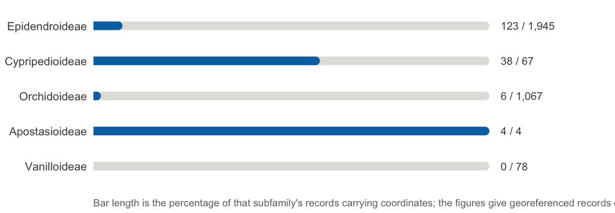

```r
valid_sf <- c("Apostasioideae", "Vanilloideae", "Cypripedioideae",
              "Orchidoideae", "Epidendroideae")

coverage <- data %>%
  mutate(sf = trimws(as.character(.data[[subf_col]]))) %>%
  filter(sf %in% valid_sf) %>%
  group_by(subfamily = sf) %>%
  summarise(in_database  = dplyr::n(),
            georeferenced = sum(row %in% map_data$row),
            .groups = "drop") %>%
  mutate(pct = 100 * georeferenced / in_database) %>%
  arrange(georeferenced) %>%
  mutate(subfamily = factor(subfamily, levels = subfamily),
         label = paste0(format(georeferenced, big.mark = ",", trim = TRUE), " / ",
                        format(in_database,   big.mark = ",", trim = TRUE)))

# Thin bars with rounded ends, drawn as round-capped segments: a recessive grey
# track for the whole, a solid bar for the part achieved. These three constants
# are reused by the pollinator figure below, so the two read as one system.
bar    <- 3.4          # bar thickness, points
track  <- "#E2E2DD"    # recessive track
accent <- "#0072B2"    # single hue: this figure encodes magnitude, not identity

ggplot(coverage, aes(y = subfamily)) +
  geom_segment(aes(x = 0, xend = 100, yend = subfamily),
               colour = track, linewidth = bar, lineend = "round") +
  # Subfamilies with no coordinates yet show an empty track rather than a stub.
  geom_segment(data = ~ subset(.x, georeferenced > 0),
               aes(x = 0, xend = pmax(pct, 0.8), yend = subfamily),
               colour = accent, linewidth = bar, lineend = "round") +
  geom_text(aes(x = 104, label = label), hjust = 0, size = 3.2, colour = "grey30") +
  scale_x_continuous(limits = c(0, 132), expand = c(0, 0)) +
  labs(x = NULL, y = NULL,
       caption = "Bar length is the percentage of that subfamily's records carrying coordinates; the figures give georeferenced records over records held.") +
  theme_minimal(base_size = 12) +
  theme(panel.grid    = element_blank(),
        axis.text.x   = element_blank(),
        axis.ticks    = element_blank(),
        plot.caption  = element_text(hjust = 0, colour = "grey45", size = 8.5,
                                     margin = margin(t = 10)),
        plot.margin   = margin(4, 4, 4, 4))
```

Composition of the mapped records by pollinator group follows, in the same colours as the map points. A record with several groups — *Cypripedium reginae* is visited by bees, a syrphid and a scarab — is counted under **each** of them, exactly as it is drawn on the map, so the bars sum to more than the number of records. *Not reported* means no pollinator is recorded anywhere in that row, and *Hymenoptera (unassigned)* marks records whose free-text entry names an order but neither a family nor a genus the parser could resolve.

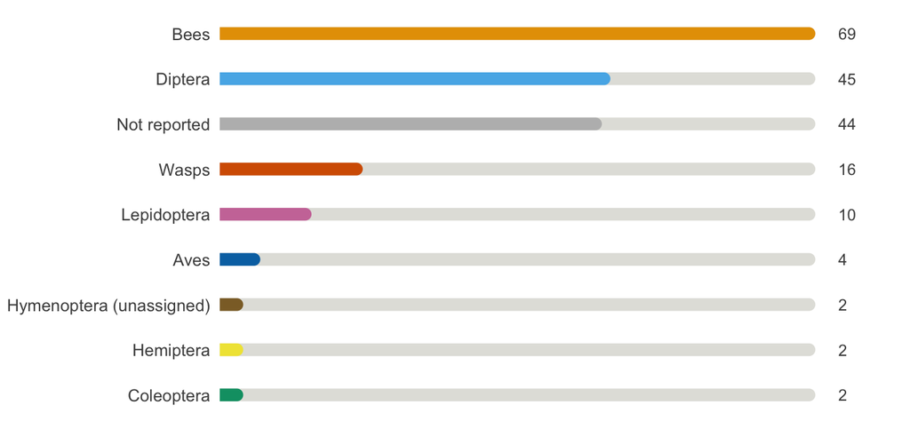

```r
# Counted the same way the map draws: a record with several groups is counted
# under each of them, so the total exceeds the number of records.
comp <- map_data %>%
  mutate(.grp = ifelse(is.na(pollinator_all) | pollinator_all == "",
                       pollinator, pollinator_all)) %>%
  tidyr::separate_rows(.grp, sep = "\\s*;\\s*") %>%
  mutate(.grp = ifelse(is.na(.grp) | .grp == "", "Not reported", .grp)) %>%
  count(pollinator = .grp, name = "records") %>%
  arrange(records) %>%
  mutate(pollinator = factor(pollinator, levels = pollinator))

ggplot(comp, aes(y = pollinator)) +
  geom_segment(aes(x = 0, xend = max(records), yend = pollinator),
               colour = track, linewidth = bar, lineend = "round") +
  geom_segment(aes(x = 0, xend = records, yend = pollinator, colour = pollinator),
               linewidth = bar, lineend = "round") +
  # The count sits at the end of every bar, so the figure never relies on
  # colour alone to be read.
  geom_text(aes(x = max(records) * 1.05, label = records),
            hjust = 0, size = 3.2, colour = "grey30") +
  scale_colour_manual(
    values = setNames(color_of(levels(comp$pollinator)), levels(comp$pollinator)),
    guide  = "none") +
  scale_x_continuous(limits = c(0, max(comp$records) * 1.16), expand = c(0, 0)) +
  labs(x = NULL, y = NULL) +
  theme_minimal(base_size = 12) +
  theme(panel.grid  = element_blank(),
        axis.text.x = element_blank(),
        axis.ticks  = element_blank(),
        plot.margin = margin(4, 4, 4, 4))
```